# Heart Disease Analysis

Link for dataset: https://www.kaggle.com/datasets/kamilpytlak/personal-key-indicators-of-heart-disease

```python
# Importing libraries

import pandas as pd
import numpy as np
import plotly.express as px
import seaborn as sns
import plotly.express as px
import matplotlib.pyplot as plt
import shap
from ydata_profiling import ProfileReport

import warnings
warnings.simplefilter(action="ignore", category=FutureWarning)
```

### Get and Inspect the Data

```python
df = pd.read_csv("heart_2022_Key_indicators.csv")
```

```python
# Seeing all columns names:
for column_headers in df.columns:
    print(column_headers)
```

```
HeartDisease
BMI
Smoking
AlcoholDrinking
Stroke
PhysicalHealth
MentalHealth
DiffWalking
Sex
AgeCategory
Race
Diabetic
PhysicalActivity
GenHealth
SleepTime
Asthma
KidneyDisease
SkinCancer
```

```python
# Sample the data
df.sample(3)
```

|  | HeartDisease | BMI | Smoking | AlcoholDrinking | Stroke | PhysicalHealth | MentalHealth | DiffWalking | Sex | AgeCategory | Race | Diabetic | PhysicalActivity | GenHealth | SleepTime | Asthma | KidneyDisease | SkinCancer |
| --- | --- | --- | --- | --- | --- | --- | --- | --- | --- | --- | --- | --- | --- | --- | --- | --- | --- | --- |
| 184219 | Yes | 28.13 | No | No | No | 30.0 | 0.0 | No | Male | 55-59 | White | No | Yes | Good | 7.0 | No | No | No |
| 180959 | No | 29.13 | Yes | No | No | 0.0 | 0.0 | Yes | Male | 70-74 | Hispanic | Yes | Yes | Good | 6.0 | Yes | No | No |
| 95247 | No | 23.40 | Yes | No | No | 1.0 | 0.0 | No | Female | 40-44 | White | No | No | Very good | 8.0 | No | No | No |

```python
# Seeing the data types
df.dtypes
```

```
HeartDisease         object
BMI                 float64
Smoking              object
AlcoholDrinking      object
Stroke               object
PhysicalHealth      float64
MentalHealth        float64
DiffWalking          object
Sex                  object
AgeCategory          object
Race                 object
Diabetic             object
PhysicalActivity     object
GenHealth            object
SleepTime           float64
Asthma               object
KidneyDisease        object
SkinCancer           object
dtype: object
```

```python
# Creating a profile for automated report
profile = ProfileReport(df, title="Heart_Disease_Report")
```

```python
#Exporting to a file
profile.to_file("Heart_Disease_Report.html")
```

```python
# Get an overview of the data
df.info()
```

```
<class 'pandas.core.frame.DataFrame'>
RangeIndex: 319795 entries, 0 to 319794
Data columns (total 18 columns):
 #   Column            Non-Null Count   Dtype
---  ------            --------------   -----
 0   HeartDisease      319795 non-null  object
 1   BMI               319795 non-null  float64
 2   Smoking           319795 non-null  object
 3   AlcoholDrinking   319795 non-null  object
 4   Stroke            319795 non-null  object
 5   PhysicalHealth    319795 non-null  float64
 6   MentalHealth      319795 non-null  float64
 7   DiffWalking       319795 non-null  object
 8   Sex               319795 non-null  object
 9   AgeCategory       319795 non-null  object
 10  Race              319795 non-null  object
 11  Diabetic          319795 non-null  object
 12  PhysicalActivity  319795 non-null  object
 13  GenHealth         319795 non-null  object
 14  SleepTime         319795 non-null  float64
 15  Asthma            319795 non-null  object
 16  KidneyDisease     319795 non-null  object
 17  SkinCancer        319795 non-null  object
dtypes: float64(4), object(14)
memory usage: 43.9+ MB
```

```python
df.isna().sum()
```

```
HeartDisease        0
BMI                 0
Smoking             0
AlcoholDrinking     0
Stroke              0
PhysicalHealth      0
MentalHealth        0
DiffWalking         0
Sex                 0
AgeCategory         0
Race                0
Diabetic            0
PhysicalActivity    0
GenHealth           0
SleepTime           0
Asthma              0
KidneyDisease       0
SkinCancer          0
dtype: int64
```

From the cells above we see that our dataframe don't have missing values!

```python
# Geerating a descriptive statistics about the data
df.describe().T
```

|  | count | mean | std | min | 25% | 50% | 75% | max |
| --- | --- | --- | --- | --- | --- | --- | --- | --- |
| BMI | 319795.0 | 28.325399 | 6.356100 | 12.02 | 24.03 | 27.34 | 31.42 | 94.85 |
| PhysicalHealth | 319795.0 | 3.371710 | 7.950850 | 0.00 | 0.00 | 0.00 | 2.00 | 30.00 |
| MentalHealth | 319795.0 | 3.898366 | 7.955235 | 0.00 | 0.00 | 0.00 | 3.00 | 30.00 |
| SleepTime | 319795.0 | 7.097075 | 1.436007 | 1.00 | 6.00 | 7.00 | 8.00 | 24.00 |

The SleepTime mean and median are close too

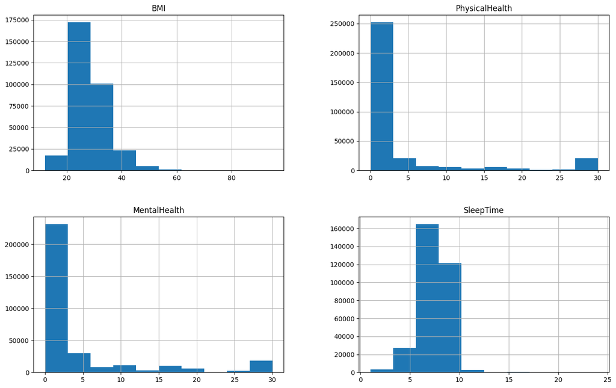

```python
hist = df.hist(figsize=(16,10))
```

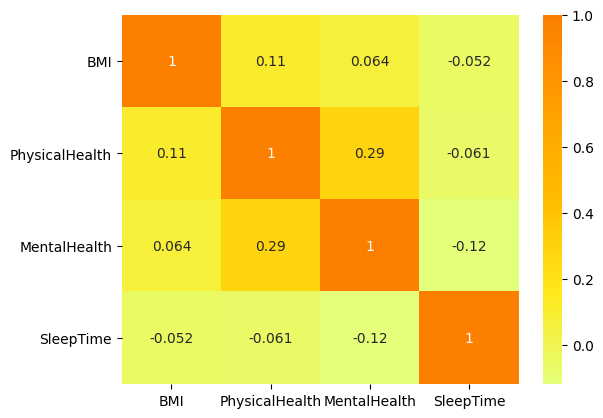

```python
# Check the Pearson's correlation
fig, ax = plt.subplots()

heatmap = sns.heatmap(
    df.corr(),
    cmap="Wistia",
    annot=True
)

corr_matrix = df.corr()
```

From the correlation matrix we can see some relationships like the "PhysicalHealth" and the "MentalHealth" are weak positive correlated. So, increasing one maybe can increase the other feature.

In addition, the "SleepTime" have a weak negative relationship with "BMI", "PhysicalHealth" and "MentalHealth", indicating that a low sleep time can impair these variables.

### Ploting some features

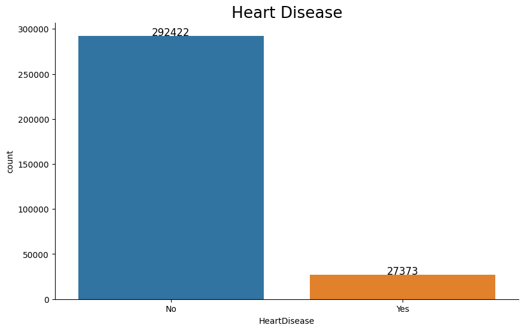

```python
fig, ax = plt.subplots(figsize=(10,6))
ax = sns.countplot(data=df, x="HeartDisease")

for rect in ax.patches:
    ax.text (rect.get_x() + rect.get_width()  / 2,rect.get_height(),rect.get_height(),
             horizontalalignment='center', fontsize = 12)

ax.spines["top"].set_visible(False)
ax.spines["right"].set_visible(False)
ax.set_title("Heart Disease", fontsize=19)
```

```python
labels = df.HeartDisease.value_counts().index
sizes = df.HeartDisease.value_counts()
```

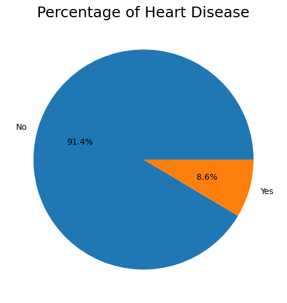

```python
fig, ax = plt.subplots(figsize=(10,6))
ax.pie(sizes, labels=labels, autopct="%1.1f%%")
ax.set_title("Percentage of Heart Disease", fontsize=18)
```

We can see that the majority of the data it's from people that do not have Heart Disease

```python
# DataFrames fo analysis with and without Heart Disease
df_HeartDisease_yes = df.query('HeartDisease == "Yes"')
df_HeartDisease_no = df.query('HeartDisease == "No"')
```

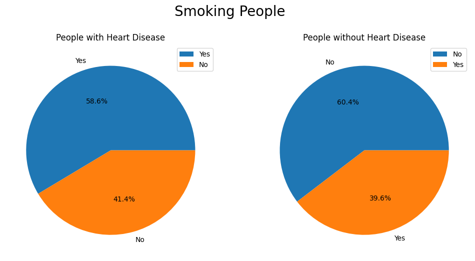

```python
labels_Smoking_HD_yes = df_HeartDisease_yes.Smoking.value_counts().index
values_Smoking_HD_yes = df_HeartDisease_yes.Smoking.value_counts()

labels_Smoking_HD_no = df_HeartDisease_no.Smoking.value_counts().index
values_Smoking_HD_no = df_HeartDisease_no.Smoking.value_counts()

fig = plt.figure(figsize=(12,6))

ax1 = fig.add_subplot(121)
ax1.pie(values_Smoking_HD_yes, labels=labels_Smoking_HD_yes, autopct="%1.1f%%")
plt.legend()
plt.title("People with Heart Disease")

plt.suptitle("Smoking People", fontsize=20)

ax2 = fig.add_subplot(122)
ax2.pie(values_Smoking_HD_no, labels=labels_Smoking_HD_no, autopct="%1.1f%%")
plt.legend()
plt.title("People without Heart Disease")
```

Dentre as pessoas com doença no coração, 58,6% afirmam fumar enquanto que dentre as pessoas sem doença no coração, esse valor cai para 39,6%. Ou seja, a maioria das pessoas sem doenças no coração tendem a não fumar (60,4%)

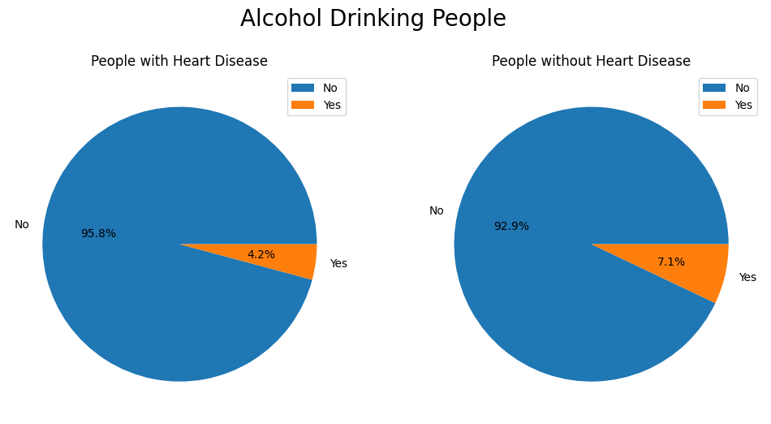

```python
labels_AlcoholDrinking_HD_yes = df_HeartDisease_yes.AlcoholDrinking.value_counts().index
values_AlcoholDrinking_HD_yes = df_HeartDisease_yes.AlcoholDrinking.value_counts()

labels_AlcoholDrinking_HD_no = df_HeartDisease_no.AlcoholDrinking.value_counts().index
values_AlcoholDrinking_HD_no = df_HeartDisease_no.AlcoholDrinking.value_counts()

fig = plt.figure(figsize=(12,6))

plt.suptitle("Alcohol Drinking People", fontsize=20)

ax1 = fig.add_subplot(121)
ax1.pie(values_AlcoholDrinking_HD_yes, labels=labels_AlcoholDrinking_HD_yes, autopct="%1.1f%%")
plt.legend()
plt.title("People with Heart Disease")

ax2 = fig.add_subplot(122)
ax2.pie(values_AlcoholDrinking_HD_no, labels=labels_AlcoholDrinking_HD_no, autopct="%1.1f%%")
plt.legend()
plt.title("People without Heart Disease")
```

We can see that most people with and without heart disease don't drink as much (above 90%). This mais indicate that there is not a strong relationship between alcohol comsumption and heart disease

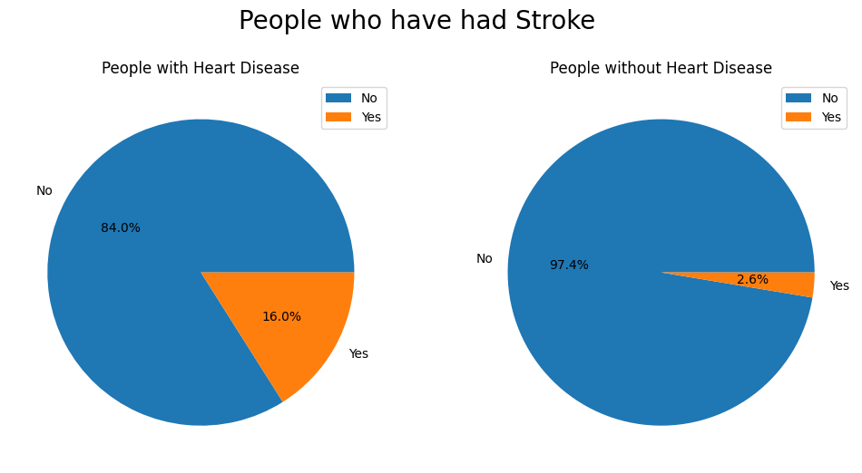

```python
labels_Stroke_HD_yes = df_HeartDisease_yes.Stroke.value_counts().index
values_Stroke_HD_yes = df_HeartDisease_yes.Stroke.value_counts()

labels_Stroke_HD_no = df_HeartDisease_no.Stroke.value_counts().index
values_Stroke_HD_no = df_HeartDisease_no.Stroke.value_counts()

fig = plt.figure(figsize=(12,6))

plt.suptitle("People who have had Stroke", fontsize=20)

ax1 = fig.add_subplot(121)
ax1.pie(values_Stroke_HD_yes, labels=labels_Stroke_HD_yes, autopct="%1.1f%%")
plt.legend()
plt.title("People with Heart Disease")

ax2 = fig.add_subplot(122)
ax2.pie(values_Stroke_HD_no, labels=labels_Stroke_HD_no, autopct="%1.1f%%")
plt.legend()
plt.title("People without Heart Disease")
```

We can see that 16% of people with heart disease had a stroke, while only 2,6% of people without heart disease had a stroke. This may indicate a slight relationship between the heart disease condition and stroke

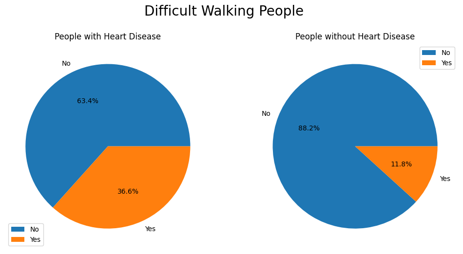

```python
labels_DiffWalking_HD_yes = df_HeartDisease_yes.DiffWalking.value_counts().index
values_DiffWalking_HD_yes = df_HeartDisease_yes.DiffWalking.value_counts()

labels_DiffWalking_HD_no = df_HeartDisease_no.DiffWalking.value_counts().index
values_DiffWalking_HD_no = df_HeartDisease_no.DiffWalking.value_counts()

fig = plt.figure(figsize=(12,6))

plt.suptitle("Difficult Walking People", fontsize=20)

ax1 = fig.add_subplot(121)
ax1.pie(values_DiffWalking_HD_yes, labels=labels_DiffWalking_HD_yes, autopct="%1.1f%%")
plt.legend()
plt.title("People with Heart Disease")

ax2 = fig.add_subplot(122)
ax2.pie(values_DiffWalking_HD_no, labels=labels_DiffWalking_HD_no, autopct="%1.1f%%")
plt.legend()
plt.title("People without Heart Disease")
```

We can see that 36,6% of people with heart disease have difficulty walking, while 11,8% of people without heart disease have the same difficulty. This may indicate that the presence of heart disease may increase the difficulty of walking and vice-versa

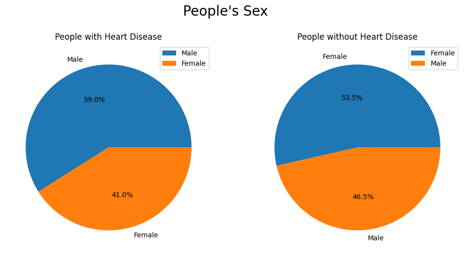

```python
labels_Sex_HD_yes = df_HeartDisease_yes.Sex.value_counts().index
values_Sex_HD_yes = df_HeartDisease_yes.Sex.value_counts()

labels_Sex_HD_no = df_HeartDisease_no.Sex.value_counts().index
values_Sex_HD_no = df_HeartDisease_no.Sex.value_counts()

fig = plt.figure(figsize=(12,6))

plt.suptitle("People's Sex", fontsize=20)

ax1 = fig.add_subplot(121)
ax1.pie(values_Sex_HD_yes, labels=labels_Sex_HD_yes, autopct="%1.1f%%")
plt.legend()
plt.title("People with Heart Disease")

ax2 = fig.add_subplot(122)
ax2.pie(values_Sex_HD_no, labels=labels_Sex_HD_no, autopct="%1.1f%%")
plt.legend()
plt.title("People without Heart Disease")
```

Among people with heart disease, most are men (59%), while among people without heart disease, most are women (53,5%). This may indicate gender differences in lifestyle such that the higher risk of heart disease is associated with men

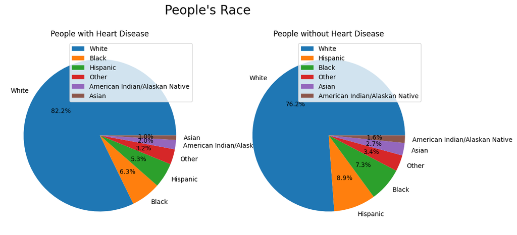

```python
labels_Race_HD_yes = df_HeartDisease_yes.Race.value_counts().index
values_Race_HD_yes = df_HeartDisease_yes.Race.value_counts()

labels_Race_HD_no = df_HeartDisease_no.Race.value_counts().index
values_Race_HD_no = df_HeartDisease_no.Race.value_counts()

fig = plt.figure(figsize=(12,6))

plt.suptitle("People's Race", fontsize=20)

ax1 = fig.add_subplot(121)
ax1.pie(values_Race_HD_yes, labels=labels_Race_HD_yes, autopct="%1.1f%%")
plt.legend(loc="upper right")
plt.title("People with Heart Disease")

ax2 = fig.add_subplot(122)
ax2.pie(values_Race_HD_no, labels=labels_Race_HD_no, autopct="%1.1f%%")
plt.legend(loc="upper right")
plt.title("People without Heart Disease")
```

We can observe that whites are the majority in the both with and without heart disease groups. This may be due to the majority of the population being white in the places where the surveys were carried out

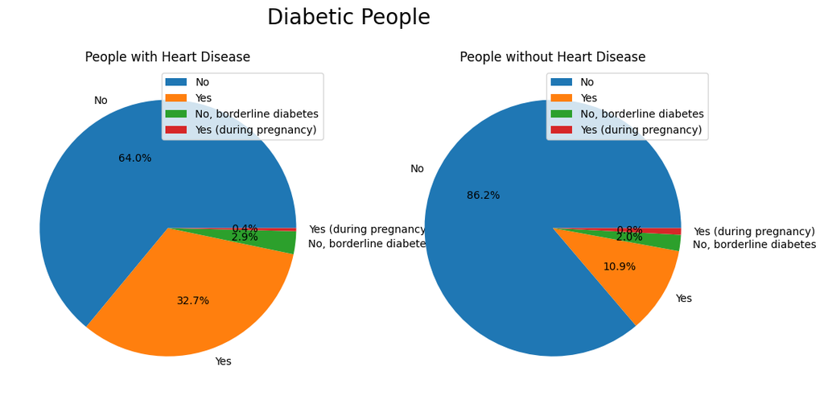

```python
labels_Diabetic_HD_yes = df_HeartDisease_yes.Diabetic.value_counts().index
values_Diabetic_HD_yes = df_HeartDisease_yes.Diabetic.value_counts()

labels_Diabetic_HD_no = df_HeartDisease_no.Diabetic.value_counts().index
values_Diabetic_HD_no = df_HeartDisease_no.Diabetic.value_counts()

fig = plt.figure(figsize=(12,6))

plt.suptitle("Diabetic People", fontsize=20)

ax1 = fig.add_subplot(121)
ax1.pie(values_Diabetic_HD_yes, labels=labels_Diabetic_HD_yes, autopct="%1.1f%%")
plt.legend()
plt.title("People with Heart Disease")

ax2 = fig.add_subplot(122)
ax2.pie(values_Diabetic_HD_no, labels=labels_Diabetic_HD_no, autopct="%1.1f%%")
plt.legend()
plt.title("People without Heart Disease")
```

Among people with heart disease, 32,7% are diabetic. While among people without heart disease this percentage drops to 10,9%. Therefore, there may be some relationship between diabetes and the incidence of heart disease

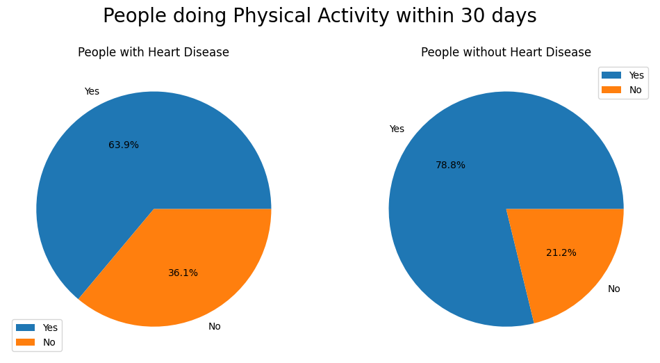

```python
labels_PhysicalActivity_HD_yes = df_HeartDisease_yes.PhysicalActivity.value_counts().index
values_PhysicalActivity_HD_yes = df_HeartDisease_yes.PhysicalActivity.value_counts()

labels_PhysicalActivity_HD_no = df_HeartDisease_no.PhysicalActivity.value_counts().index
values_PhysicalActivity_HD_no = df_HeartDisease_no.PhysicalActivity.value_counts()

fig = plt.figure(figsize=(12,6))

plt.suptitle("People doing Physical Activity within 30 days", fontsize=20)

ax1 = fig.add_subplot(121)
ax1.pie(values_PhysicalActivity_HD_yes, labels=labels_PhysicalActivity_HD_yes, autopct="%1.1f%%")
plt.legend()
plt.title("People with Heart Disease")

ax2 = fig.add_subplot(122)
ax2.pie(values_PhysicalActivity_HD_no, labels=labels_PhysicalActivity_HD_no, autopct="%1.1f%%")
plt.legend()
plt.title("People without Heart Disease")
```

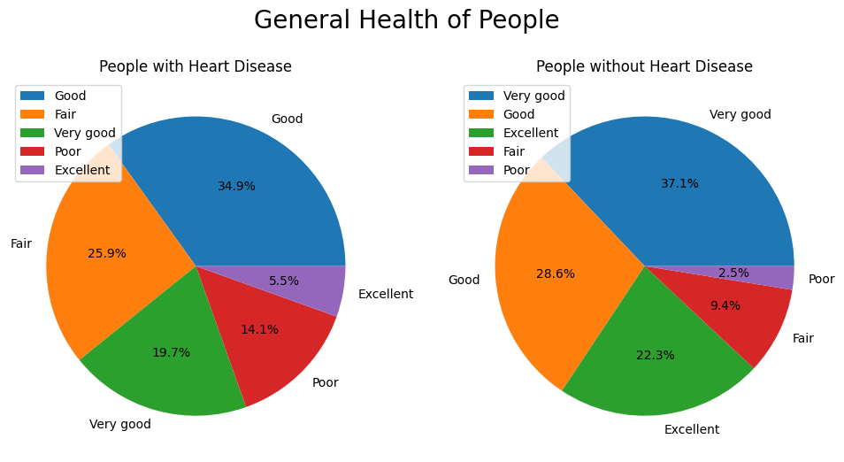

```python
labels_GenHealth_HD_yes = df_HeartDisease_yes.GenHealth.value_counts().index
values_GenHealth_HD_yes = df_HeartDisease_yes.GenHealth.value_counts()

labels_GenHealth_HD_no = df_HeartDisease_no.GenHealth.value_counts().index
values_GenHealth_HD_no = df_HeartDisease_no.GenHealth.value_counts()

fig = plt.figure(figsize=(12,6))

plt.suptitle("General Health of People", fontsize=20)

ax1 = fig.add_subplot(121)
ax1.pie(values_GenHealth_HD_yes, labels=labels_GenHealth_HD_yes, autopct="%1.1f%%")
plt.legend(loc="upper left")
plt.title("People with Heart Disease")

ax2 = fig.add_subplot(122)
ax2.pie(values_GenHealth_HD_no, labels=labels_GenHealth_HD_no, autopct="%1.1f%%")
plt.legend(loc="upper left")
plt.title("People without Heart Disease")
```

We can see that among people with heart disease 14,1% have poor health and 25,9% have fair health while these values are 2,5% and 9,4% among people without heart disease, respectively. In this way, we can see that the general health of people without heart disease is better compared to people with heart disease

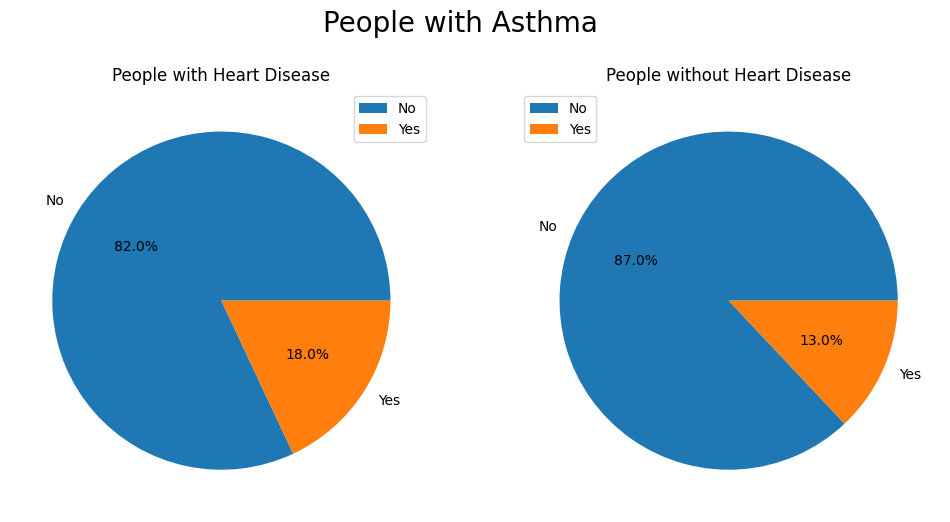

```python
labels_Asthma_HD_yes = df_HeartDisease_yes.Asthma.value_counts().index
values_Asthma_HD_yes = df_HeartDisease_yes.Asthma.value_counts()

labels_Asthma_HD_no = df_HeartDisease_no.Asthma.value_counts().index
values_Asthma_HD_no = df_HeartDisease_no.Asthma.value_counts()

fig = plt.figure(figsize=(12,6))

plt.suptitle("People with Asthma", fontsize=20)

ax1 = fig.add_subplot(121)
ax1.pie(values_Asthma_HD_yes, labels=labels_Asthma_HD_yes, autopct="%1.1f%%")
plt.legend()
plt.title("People with Heart Disease")

ax2 = fig.add_subplot(122)
ax2.pie(values_Asthma_HD_no, labels=labels_Asthma_HD_no, autopct="%1.1f%%")
plt.legend(loc="upper left")
plt.title("People without Heart Disease")
```

In people with heart disease, 18% have Asthma. This value drops to 13% in people without heart disease. based on this variation, it is not possible to conclude whether there is a direct relationship between asthma and heart disease.

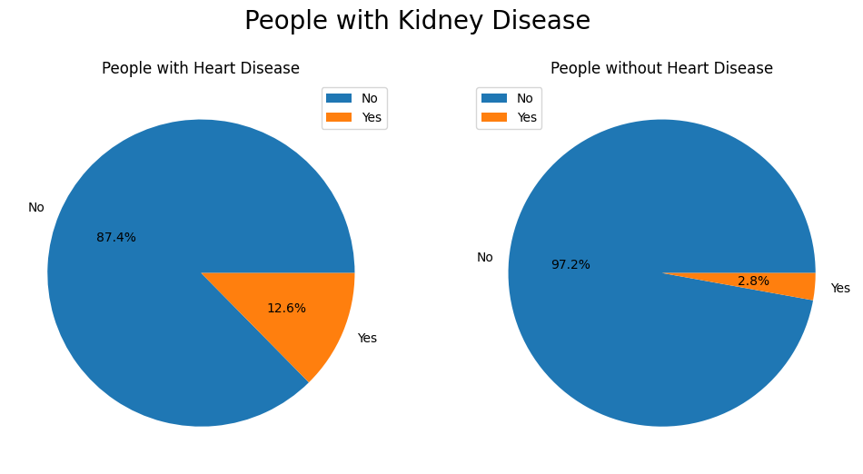

```python
labels_KidneyDisease_HD_yes = df_HeartDisease_yes.KidneyDisease.value_counts().index
values_KidneyDisease_HD_yes = df_HeartDisease_yes.KidneyDisease.value_counts()

labels_KidneyDisease_HD_no = df_HeartDisease_no.KidneyDisease.value_counts().index
values_KidneyDisease_HD_no = df_HeartDisease_no.KidneyDisease.value_counts()

fig = plt.figure(figsize=(12,6))

plt.suptitle("People with Kidney Disease", fontsize=20)

ax1 = fig.add_subplot(121)
ax1.pie(values_KidneyDisease_HD_yes, labels=labels_KidneyDisease_HD_yes, autopct="%1.1f%%")
plt.legend()
plt.title("People with Heart Disease")

ax2 = fig.add_subplot(122)
ax2.pie(values_KidneyDisease_HD_no, labels=labels_KidneyDisease_HD_no, autopct="%1.1f%%")
plt.legend(loc="upper left")
plt.title("People without Heart Disease")
```

In people with heart disease, 12,6% have kidney disease. This value drops to 2,8% in people without heart disease. Due to thsi variation, it is possible that kidney disease and heart disease are related. In addition, kidney disease weakens the person's health, which could facilitate the emergence of other diseases, such as heart disease and vice-versa

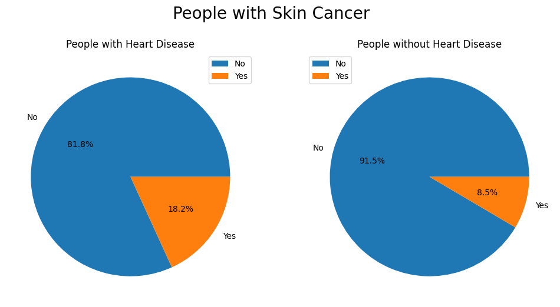

```python
labels_SkinCancer_HD_yes = df_HeartDisease_yes.SkinCancer.value_counts().index
values_SkinCancer_HD_yes = df_HeartDisease_yes.SkinCancer.value_counts()

labels_SkinCancer_HD_no = df_HeartDisease_no.SkinCancer.value_counts().index
values_SkinCancer_HD_no = df_HeartDisease_no.SkinCancer.value_counts()

fig = plt.figure(figsize=(12,6))

plt.suptitle("People with Skin Cancer", fontsize=20)

ax1 = fig.add_subplot(121)
ax1.pie(values_SkinCancer_HD_yes, labels=labels_SkinCancer_HD_yes, autopct="%1.1f%%")
plt.legend()
plt.title("People with Heart Disease")

ax2 = fig.add_subplot(122)
ax2.pie(values_SkinCancer_HD_no, labels=labels_SkinCancer_HD_no, autopct="%1.1f%%")
plt.legend(loc="upper left")
plt.title("People without Heart Disease")
```

In people with heart disease, 18,2% have skin cancer. This value drops to 8,5% in peole without heart disease. Due to this variation, it is possible that skin cancer and heart disease are related. In additon, skin cancer weakens the person's health, which could facilitate the emergence of other diseases, such as heart disease and vice-versa

```
28.325398520926328
```

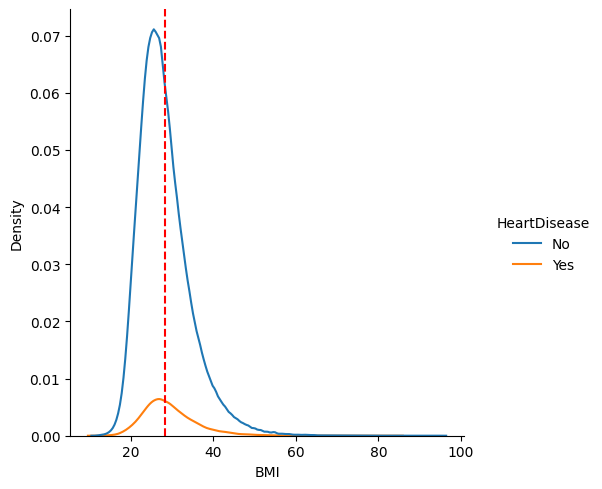

```python
sns.displot(
    data=df,
    x="BMI",
    kind="kde",
    hue="HeartDisease"

)
plt.axvline(np.mean(df["BMI"]),ls="--", color="red")
print(np.mean(df["BMI"]))
```

```
3.3717100017198516
```

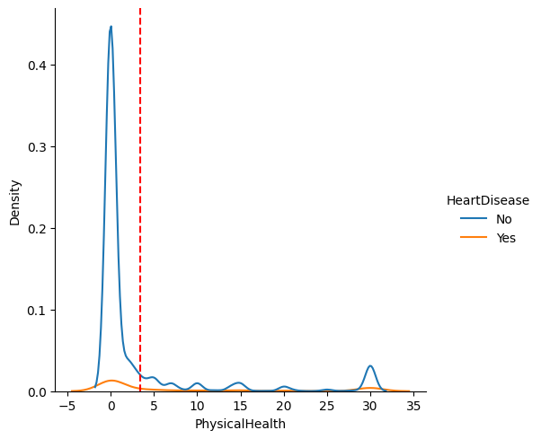

```python
sns.displot(
    data=df,
    x="PhysicalHealth",
    kind="kde",
    hue="HeartDisease"

)
plt.axvline(np.mean(df["PhysicalHealth"]),ls="--", color="red")
print(np.mean(df["PhysicalHealth"]))
```

```
3.898366140808956
```

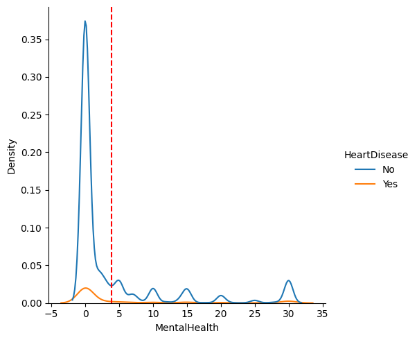

```python
sns.displot(
    data=df,
    x="MentalHealth",
    kind="kde",
    hue="HeartDisease"

)
plt.axvline(np.mean(df["MentalHealth"]),ls="--", color="red")
print(np.mean(df["MentalHealth"]))
```

## Creating the models

First we need to deal with the categorical features. For them, we will create a mapping of the categorical values and use an ordinal encoder

```python
df.head(3)
```

|  | HeartDisease | BMI | Smoking | AlcoholDrinking | Stroke | PhysicalHealth | MentalHealth | DiffWalking | Sex | AgeCategory | Race | Diabetic | PhysicalActivity | GenHealth | SleepTime | Asthma | KidneyDisease | SkinCancer |
| --- | --- | --- | --- | --- | --- | --- | --- | --- | --- | --- | --- | --- | --- | --- | --- | --- | --- | --- |
| 0 | No | 16.60 | Yes | No | No | 3.0 | 30.0 | No | Female | 55-59 | White | Yes | Yes | Very good | 5.0 | Yes | No | Yes |
| 1 | No | 20.34 | No | No | Yes | 0.0 | 0.0 | No | Female | 80 or older | White | No | Yes | Very good | 7.0 | No | No | No |
| 2 | No | 26.58 | Yes | No | No | 20.0 | 30.0 | No | Male | 65-69 | White | Yes | Yes | Fair | 8.0 | Yes | No | No |

```python
# Mapping of the categorical features
ordinal_cols_mapping = [{
    "col": "HeartDisease",
    "mapping": {
        'No': 0,
        'Yes': 1
    }}, {
    "col": "Smoking",
    "mapping": {
        'No': 0,
        'Yes': 1
    }}, {
    "col": "AlcoholDrinking",
    "mapping": {
        'No': 0,
        'Yes': 1
    }}, {
    "col": "Stroke",
    "mapping": {
        'No': 0,
        'Yes': 1,
    }}, {
    "col": "DiffWalking",
    "mapping": {
        'No': 0,
        'Yes': 1,
    }}, {
    "col": "Sex",
    "mapping": {
        'Male': 0,
        'Female': 1,
    }}, {
    "col": "Diabetic",
    "mapping": {
        'No': 0,
        'Yes': 1,
        'No, borderline diabetes': 2,
        'Yes (during pregnancy)': 3
    }}, {
    "col": "PhysicalActivity",
    "mapping": {
        'No': 0,
        'Yes': 1,
    }}, {
    "col": "Asthma",
    "mapping": {
        'No': 0,
        'Yes': 1,
    }}, {
    "col": "KidneyDisease",
    "mapping": {
        'No': 0,
        'Yes': 1,
    }}, {
    "col": "SkinCancer",
    "mapping": {
        'No': 0,
        'Yes': 1,
    }}, {
    "col": "AgeCategory",
    "mapping": {
        '18-24': 0,
        '25-29': 1,
        '30-34': 2,
        '35-39': 3,
        '40-44': 4,
        '45-49': 5,
        '50-54': 6,
        '55-59': 7,
        '60-64': 8,
        '65-69': 9,
        '70-74': 10,
        '75-79': 11,
        '80 or older': 12,
    }}, {
    "col": "Race",
    "mapping": {
        'American Indian/Alaskan Native': 0,
        'Asian': 1,
        'Black': 2,
        'Hispanic': 3,
        'Other': 4,
        'White': 5,
    }}, {
    "col": "GenHealth",
    "mapping": {
        'Poor': -2,
        'Fair': -1,
        'Good': 0,
        'Very good': 1,
        'Excellent': 2,
    }}
]
```

```python
from sklearn.preprocessing import LabelEncoder
```

```python
import category_encoders as ce
encoder = ce.OrdinalEncoder(mapping = ordinal_cols_mapping,
                           return_df=True)
```

```python
# Encoding the dataframe
df_encoded = encoder.fit_transform(df)
```

```python
df_encoded.sample(3)
```

|  | HeartDisease | BMI | Smoking | AlcoholDrinking | Stroke | PhysicalHealth | MentalHealth | DiffWalking | Sex | AgeCategory | Race | Diabetic | PhysicalActivity | GenHealth | SleepTime | Asthma | KidneyDisease | SkinCancer |
| --- | --- | --- | --- | --- | --- | --- | --- | --- | --- | --- | --- | --- | --- | --- | --- | --- | --- | --- |
| 191110 | 0 | 24.13 | 0 | 0 | 0 | 0.0 | 14.0 | 0 | 1 | 8 | 2 | 1 | 1 | -1 | 7.0 | 0 | 0 | 0 |
| 187546 | 0 | 29.95 | 1 | 1 | 0 | 0.0 | 10.0 | 0 | 0 | 6 | 5 | 0 | 1 | 0 | 7.0 | 0 | 0 | 0 |
| 204374 | 1 | 30.52 | 1 | 0 | 0 | 30.0 | 25.0 | 1 | 0 | 6 | 5 | 0 | 0 | -2 | 5.0 | 0 | 0 | 0 |

```python
# Creating the features dataframe
X = df_encoded.drop(columns="HeartDisease")
X.sample(3)
```

|  | BMI | Smoking | AlcoholDrinking | Stroke | PhysicalHealth | MentalHealth | DiffWalking | Sex | AgeCategory | Race | Diabetic | PhysicalActivity | GenHealth | SleepTime | Asthma | KidneyDisease | SkinCancer |
| --- | --- | --- | --- | --- | --- | --- | --- | --- | --- | --- | --- | --- | --- | --- | --- | --- | --- |
| 316005 | 25.99 | 0 | 0 | 0 | 0.0 | 0.0 | 0 | 0 | 0 | 3 | 0 | 1 | 2 | 8.0 | 0 | 0 | 0 |
| 286485 | 29.18 | 0 | 0 | 0 | 0.0 | 0.0 | 0 | 1 | 6 | 5 | 0 | 1 | 1 | 8.0 | 0 | 0 | 1 |
| 143584 | 25.99 | 0 | 0 | 0 | 0.0 | 0.0 | 0 | 1 | 11 | 5 | 1 | 1 | 1 | 8.0 | 0 | 0 | 0 |

```python
# Creating the target
y = df_encoded["HeartDisease"]
y.sample(3)
```

```
11063    0
86725    0
65228    0
Name: HeartDisease, dtype: int32
```

```python
# Seeing all columns names:
for column_headers in X.columns:
    print(column_headers)
```

```
BMI
Smoking
AlcoholDrinking
Stroke
PhysicalHealth
MentalHealth
DiffWalking
Sex
AgeCategory
Race
Diabetic
PhysicalActivity
GenHealth
SleepTime
Asthma
KidneyDisease
SkinCancer
```

### Importing the models

```python
from sklearn.model_selection import train_test_split
from sklearn.tree import DecisionTreeClassifier
from xgboost import XGBClassifier
from sklearn.naive_bayes import GaussianNB
import lightgbm as lgb
from sklearn import metrics
```

```python
from tqdm import tqdm
```

### Decision Tree Classifier

```python
# Instanciando o modelo antes do loop
# Não utilizar o "random_state" pois irá ativar um seed que repetirá a amostragem

# Pré-alocando
tree_precision = []
tree_accuracy = []
tree_recall = []
tree_f1 = []

X_train, X_test, y_train, y_test = train_test_split(X, y, test_size=0.33, stratify=y)
tree_classifier = DecisionTreeClassifier()

for i in tqdm(range(50)):

    tree_classifier.fit(X_train, y_train)
    # Metrics
    precision = metrics.precision_score(y_test, tree_classifier.predict(X_test))
    accuracy = metrics.accuracy_score(y_test, tree_classifier.predict(X_test))
    recall = metrics.recall_score(y_test, tree_classifier.predict(X_test))
    f1 = metrics.f1_score(y_test, tree_classifier.predict(X_test))
    # Append values
    tree_precision.append(precision)
    tree_accuracy.append(accuracy)
    tree_recall.append(recall)
    tree_f1.append(f1)
```

### LGBM Classifier

```python
# Pré-alocando
lgb_precision = []
lgb_accuracy = []
lgb_recall = []
lgb_f1 = []

X_train, X_test, y_train, y_test = train_test_split(X, y, test_size=0.33, stratify=y)
lgb_classifier = lgb.LGBMClassifier()

for i in tqdm(range(50)):

    lgb_classifier.fit(X_train, y_train)
    # Metrics
    precision = metrics.precision_score(y_test, lgb_classifier.predict(X_test))
    accuracy = metrics.accuracy_score(y_test, lgb_classifier.predict(X_test))
    recall = metrics.recall_score(y_test, lgb_classifier.predict(X_test))
    f1 = metrics.f1_score(y_test, lgb_classifier.predict(X_test))
    # Append values
    lgb_precision.append(precision)
    lgb_accuracy.append(accuracy)
    lgb_recall.append(recall)
    lgb_f1.append(f1)
```

### XGBClassifier

```python
# Pré-alocando
xgb_precision = []
xgb_accuracy = []
xgb_recall = []
xgb_f1 = []

X_train, X_test, y_train, y_test = train_test_split(X,y, test_size=0.33,stratify=y)
xgb_classifier = XGBClassifier()

for i in tqdm(range(50)):

    xgb_classifier.fit(X_train, y_train)
    # Metrics
    precision = metrics.precision_score(y_test, xgb_classifier.predict(X_test))
    accuracy = metrics.accuracy_score(y_test, xgb_classifier.predict(X_test))
    recall = metrics.recall_score(y_test, xgb_classifier.predict(X_test))
    f1 = metrics.f1_score(y_test, xgb_classifier.predict(X_test))
    # Append values
    xgb_precision.append(precision)
    xgb_accuracy.append(accuracy)
    xgb_recall.append(recall)
    xgb_f1.append(f1)
```

### Gaussian NB

```python
# Pré-alocando
gaussian_precision = []
gaussian_accuracy = []
gaussian_recall = []
gaussian_f1 = []

X_train, X_test, y_train, y_test = train_test_split(X,y, test_size=0.33,stratify=y)

gaussian_classifier = GaussianNB()

for i in tqdm(range(50)):

    gaussian_classifier.fit(X_train, y_train)
    # Metrics
    precision = metrics.precision_score(y_test, gaussian_classifier.predict(X_test))
    accuracy = metrics.accuracy_score(y_test, gaussian_classifier.predict(X_test))
    recall = metrics.recall_score(y_test, gaussian_classifier.predict(X_test))
    f1 = metrics.f1_score(y_test, gaussian_classifier.predict(X_test))
    # Append values
    gaussian_precision.append(precision)
    gaussian_accuracy.append(accuracy)
    gaussian_recall.append(recall)
    gaussian_f1.append(f1)
```

Preparing the metrics data to plot

```python
# Preparing the data results to plot
precision_comparison = pd.DataFrame({"DecisionTree":tree_precision,
                                     "LGBM":lgb_precision,
                                     "XGB":xgb_precision,
                                     "Gaussian":gaussian_precision,
                                     })

accuracy_comparison = pd.DataFrame({"DecisionTree":tree_accuracy,
                                    "LGBM":lgb_accuracy,
                                    "XGB":xgb_accuracy,
                                    "Gaussian":gaussian_accuracy,
                                    })

recall_comparison = pd.DataFrame({"DecisionTree":tree_recall,
                                  "LGBM":lgb_recall,
                                  "XGB":xgb_recall,
                                  "Gaussian":gaussian_recall,
                                  })

f1_comparison = pd.DataFrame({"DecisionTree":tree_f1,
                              "LGBM":lgb_f1,
                              "XGB":xgb_f1,
                              "Gaussian":gaussian_f1,
                              })
```

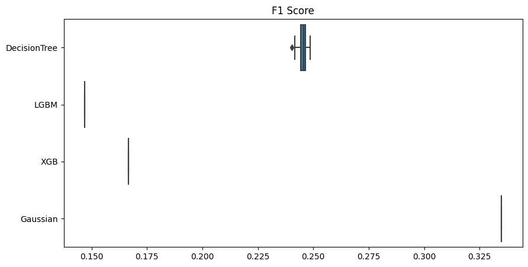

```python
fig = plt.figure(figsize = (10,5))
b = sns.boxplot(data=f1_comparison, orient="h").set(title="F1 Score")
```

```
[Text(0.5, 1.0, 'Precision Score')]
```

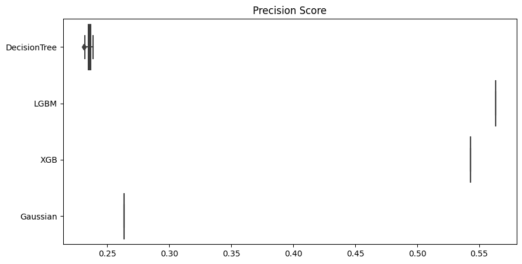

```python
fig = plt.figure(figsize = (10,5))
sns.boxplot(data=precision_comparison, orient="h").set(title="Precision Score")
```

```
[Text(0.5, 1.0, 'Recall Score')]
```

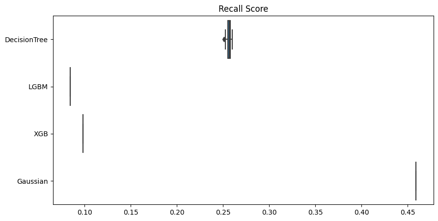

```python
fig = plt.figure(figsize = (10,5))
sns.boxplot(data=recall_comparison, orient="h").set(title="Recall Score")
```

```
[Text(0.5, 1.0, 'Accuracy Score')]
```

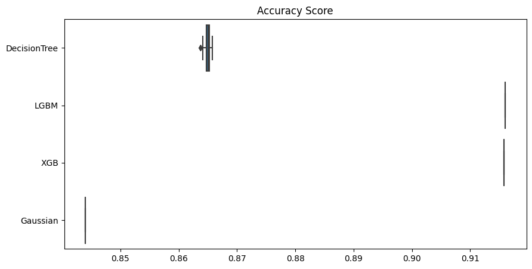

```python
fig = plt.figure(figsize = (10,5))
sns.boxplot(data=accuracy_comparison, orient="h").set(title="Accuracy Score")
```

Mean values of the metrics

```python
# Decision tree mean values
tree_precision_mean = np.mean(tree_precision).round(2)
tree_accuracy_mean = np.mean(tree_accuracy).round(2)
tree_recall_mean = np.mean(tree_recall).round(2)
tree_f1_mean = np.mean(tree_f1).round(2)
```

```python
# LGBM mean values
lgb_precision_mean = np.mean(lgb_precision).round(2)
lgb_accuracy_mean = np.mean(lgb_accuracy).round(2)
lgb_recall_mean = np.mean(lgb_recall).round(2)
lgb_f1_mean = np.mean(lgb_f1).round(2)
```

```python
# XGB mean values
xgb_precision_mean = np.mean(xgb_precision).round(2)
xgb_accuracy_mean = np.mean(xgb_accuracy).round(2)
xgb_recall_mean = np.mean(xgb_recall).round(2)
xgb_f1_mean = np.mean(xgb_f1).round(2)
```

```python
# GaussianNB mean values
gaussian_precision_mean = np.mean(gaussian_precision).round(2)
gaussian_accuracy_mean = np.mean(gaussian_accuracy).round(2)
gaussian_recall_mean = np.mean(gaussian_recall).round(2)
gaussian_f1_mean = np.mean(gaussian_f1).round(2)
```

```python
data = {"Precision": [tree_precision_mean, lgb_precision_mean, gaussian_precision_mean, xgb_precision_mean],
        "Accuracy": [tree_accuracy_mean, lgb_accuracy_mean, gaussian_accuracy_mean, xgb_accuracy_mean],
        "Recall": [tree_recall_mean, lgb_recall_mean, gaussian_recall_mean, xgb_recall_mean],
        "F1": [tree_f1_mean, lgb_f1_mean, gaussian_f1_mean, xgb_f1_mean]
       }
```

```python
mean_metrics = pd.DataFrame(data, index=["DecisionTree",
                                  "LGBM",
                                  "GaussianNB",
                                  "XGBoost"
                                 ])
```

```python
mean_metrics
```

|  | Precision | Accuracy | Recall | F1 |
| --- | --- | --- | --- | --- |
| DecisionTree | 0.24 | 0.86 | 0.26 | 0.25 |
| LGBM | 0.56 | 0.92 | 0.08 | 0.15 |
| GaussianNB | 0.26 | 0.84 | 0.46 | 0.33 |
| XGBoost | 0.54 | 0.92 | 0.10 | 0.17 |